# TCCFP Spring Meeting 2021

Geoff Miller

3/16/2021

## Sex by species

- 1 male coyote was not collared (captured at same time/location as one that was collared).
- 1 female red fox not collared (mortality, killed in trap by coyote).

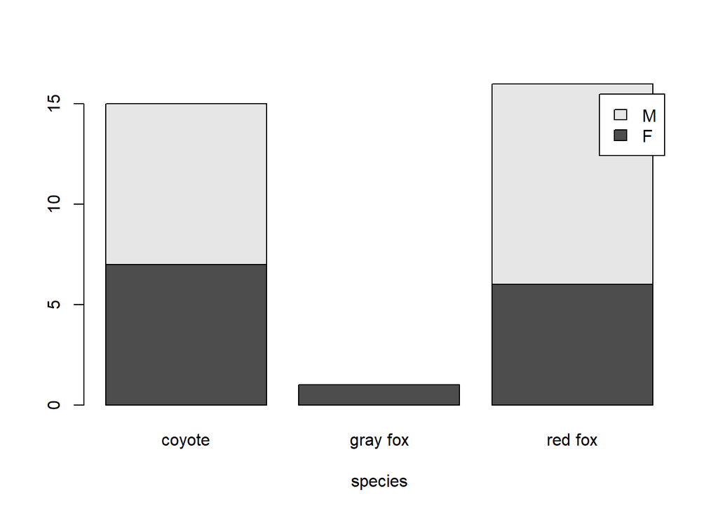

## Whether scat sample was collected.

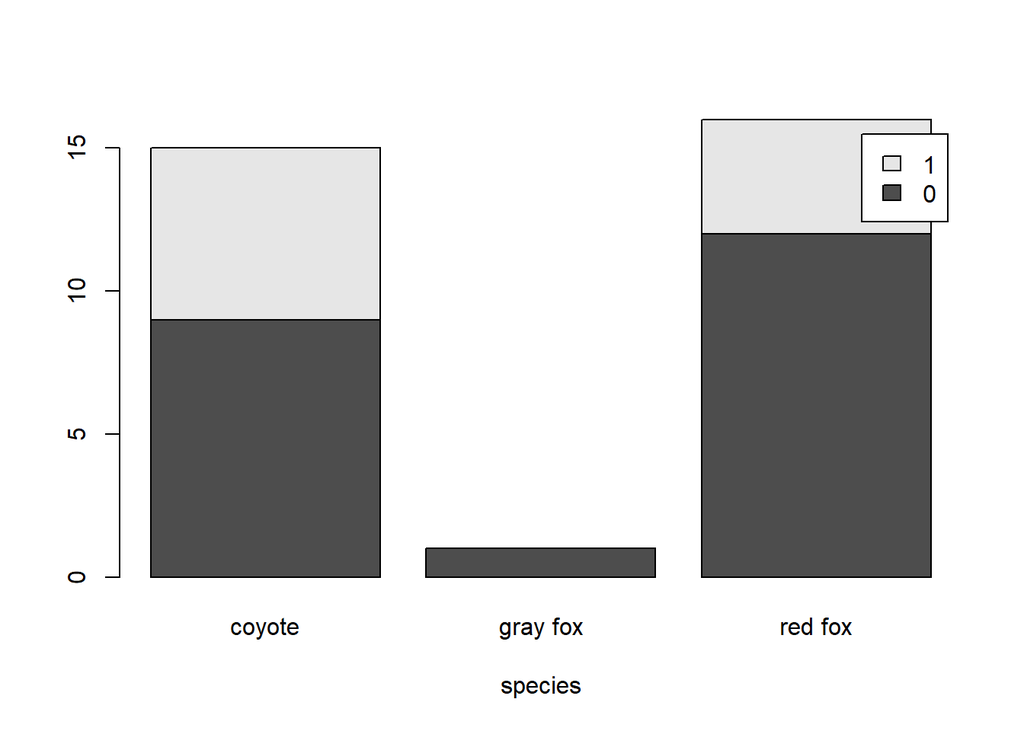

## Whether fecal sample was collected.

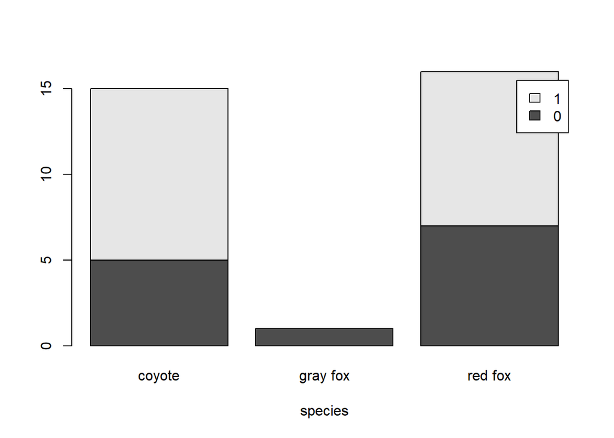

## Whether hair sample was collected.

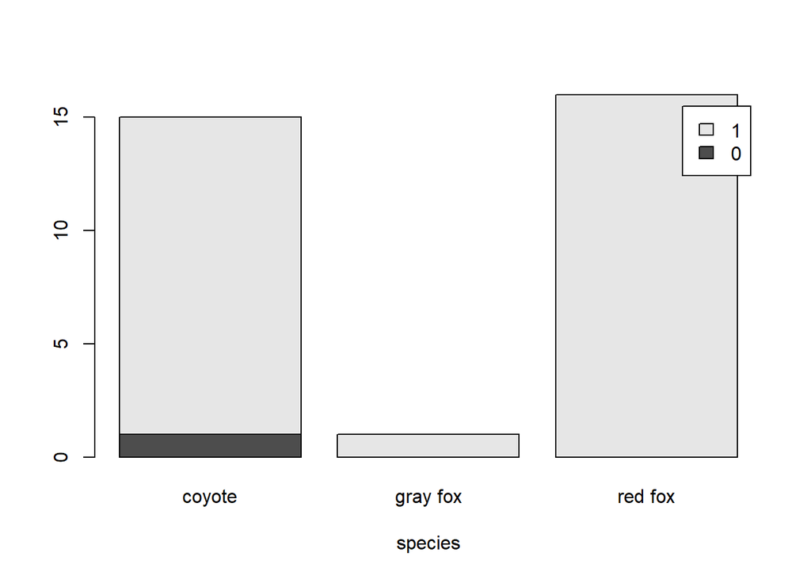

## Serum volumes

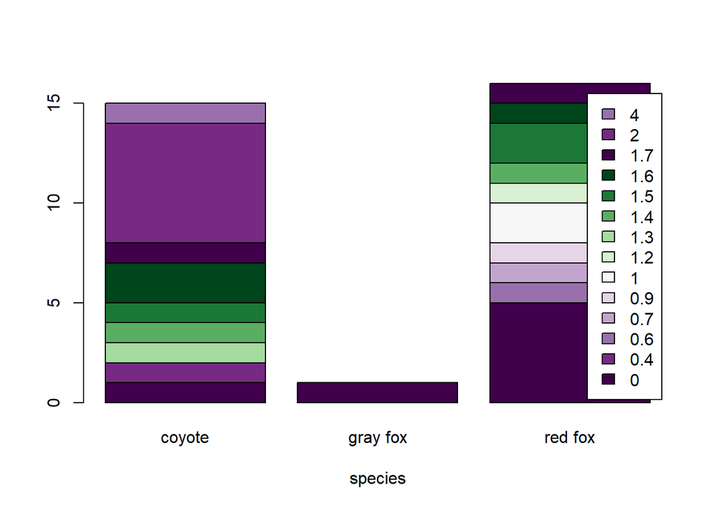

## Mortalities and causes

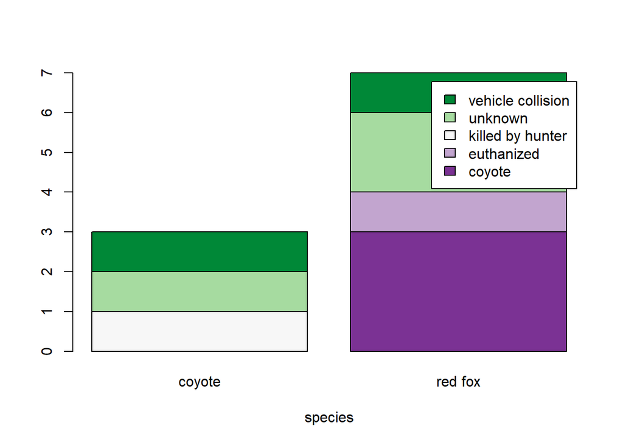

- This is an extremely high incidence of coyote killings - which are typically regarded as a perceived risk in the literature that is rarely realized. With 3/7 of our red fox deaths (and an additional attack that did not result in mortality) on the project, it seams to be a significant mortality risk in this population.
- One of the ‘free-ranging’ foxes had mange as a co-morbidity, other was seemingly healthy besides injuries incurred in attacks.

## Map of all locations to date.

- 7 coyote collars dropped off or collected from mortality
- 6/7 of those collars have had the full datalog file retrieved from the collar (1 was too chewed up by coyote’s mate, inquiring with Telonics about work-arounds)
- 6 fox collars retrieved from mortalities
- all of those datalogs retrieved
- 7 coyote collars currently deployed and contining to collect data
- 10 fox collars currently deployed and continuing to collect data

[interactive chart not shown]

## Urbanization in the TCMA.

#### Urbanization index is arbitrary - population is given a weight 5 times percent impervious surface.

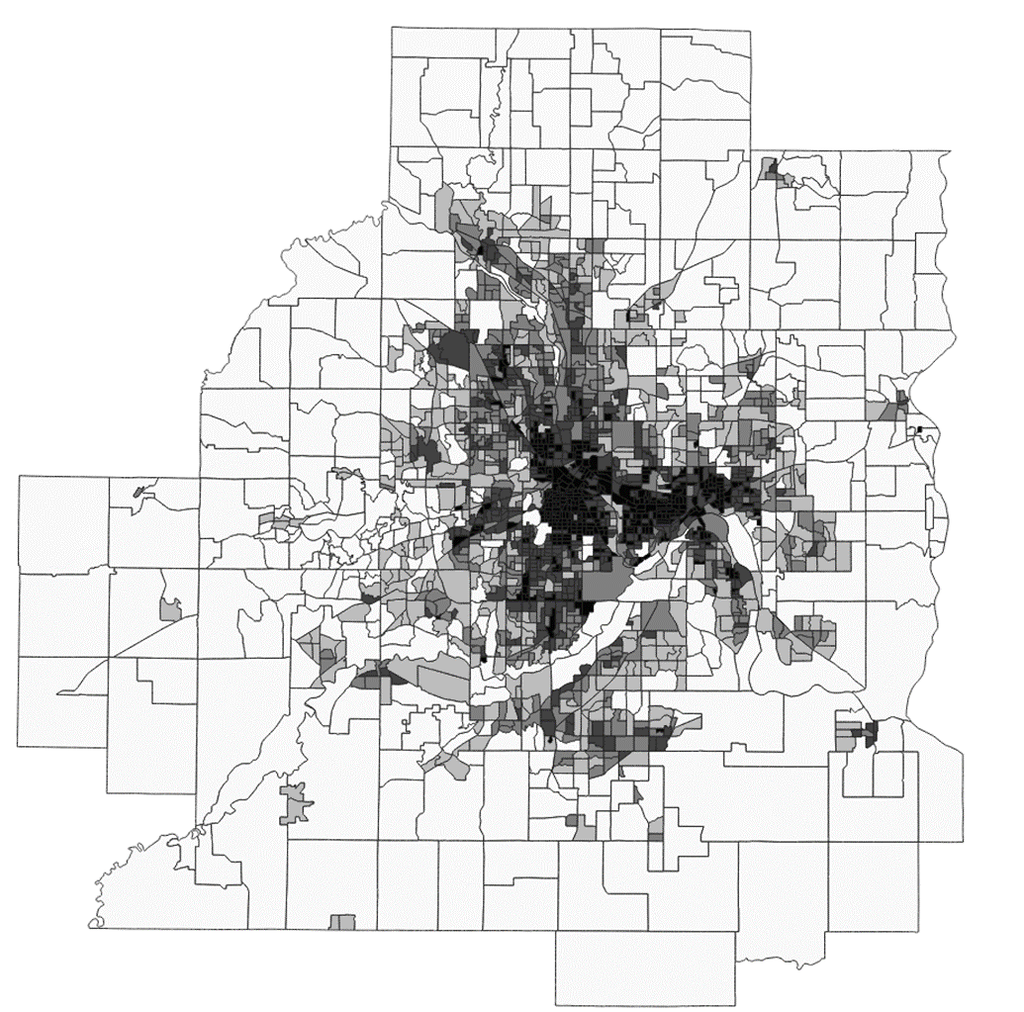

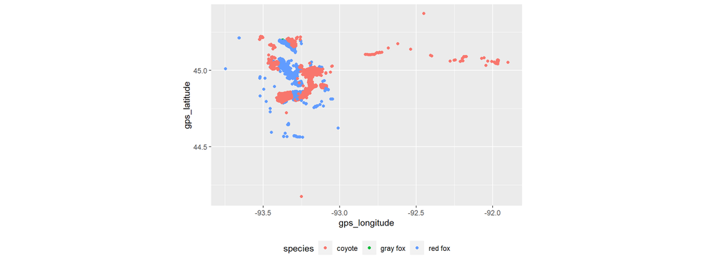